# Final Project

December 20, 2018

## Introduction

- From Kaggle
- Contains information on default payments, demographic factors, credit data, history of payment, and bill statements of credit card clients in Taiwan from April 2005 to September 2005.
- 25 variables
- 30,000 observations
- Target variable is default payment and it is binary
- 1 means defaulted and 0 means not defaulted.

## Libraries

```r
library(caret)
library(ranger)
library(readr)
```

```r
library(ggplot2)
```

## Bringing in the data

```r
setwd("C:/Users/student/Desktop/Fall 2018/R Class/Datasets")
cr = read.csv("CreditCard.csv")

cr$default.payment.next.month = factor(cr$default.payment.next.month)
cr$SEX = factor(cr$SEX)
cr$EDUCATION = factor(cr$EDUCATION)
cr$MARRIAGE = factor(cr$MARRIAGE)
```

## Visualization

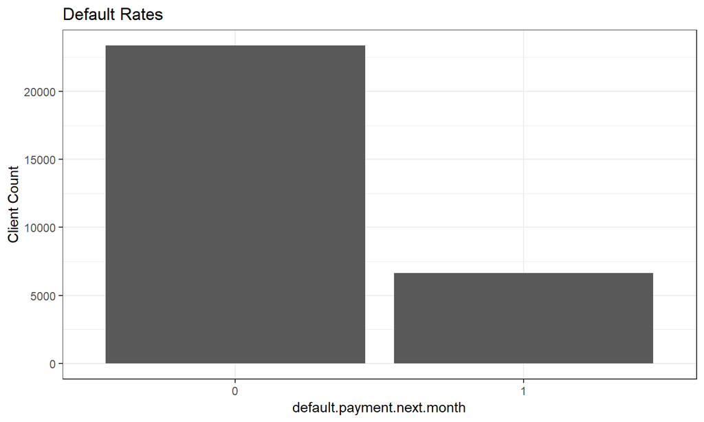

```r
# Graphing With one variable (1)
ggplot(cr, aes(x = default.payment.next.month)) + theme_bw() + geom_bar() + labs(y = "Client Count", title = "Default Rates")
```

```r
prop.table(table(cr$default.payment.next.month))
```

```
##
##      0      1
## 0.7788 0.2212
```

## Visualization 2

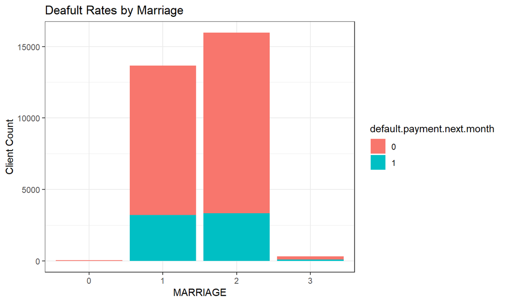

```r
# Graphing With two varialbes (2)
ggplot(cr, aes(x = MARRIAGE, fill = default.payment.next.month)) + theme_bw() + geom_bar() + labs(y = "Client Count", title = "Deafult Rates by Marriage")
```

## Visualization 3

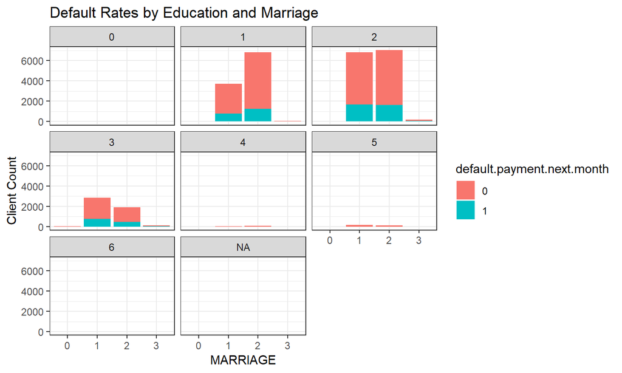

```r
# Graphing With three variables (3)
ggplot(cr, aes(x = MARRIAGE, fill = default.payment.next.month)) + theme_bw() + facet_wrap(~ EDUCATION) + geom_bar() + labs(y = "Client Count", title = "Default Rates by Education and Marriage")
```

## Visualization 4

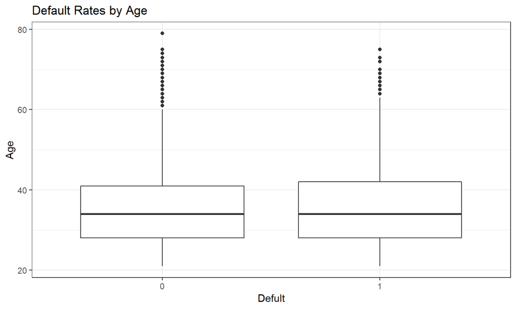

```r
ggplot(cr, aes(x = default.payment.next.month, y = AGE)) + theme_bw() + geom_boxplot() + labs(y = "Age", x = "Defult", title = "Default Rates by Age")
```

## Visualization 5

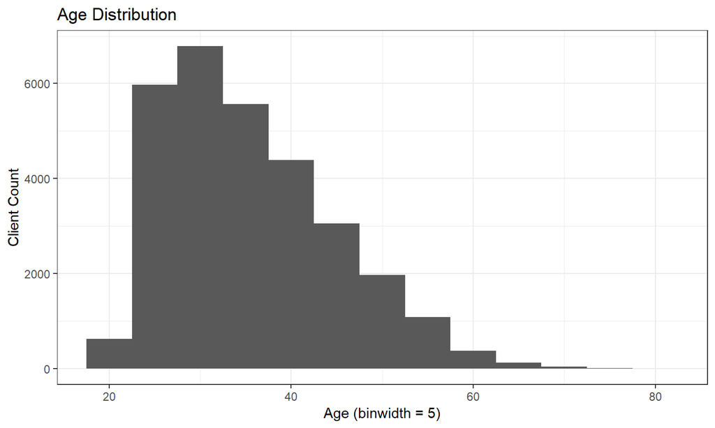

```r
ggplot(cr, aes(x = AGE)) + theme_bw() + geom_histogram(binwidth = 5) + labs(y = "Client Count", x = "Age (binwidth = 5)", title = "Age Distribution")
```

## Visualization 6

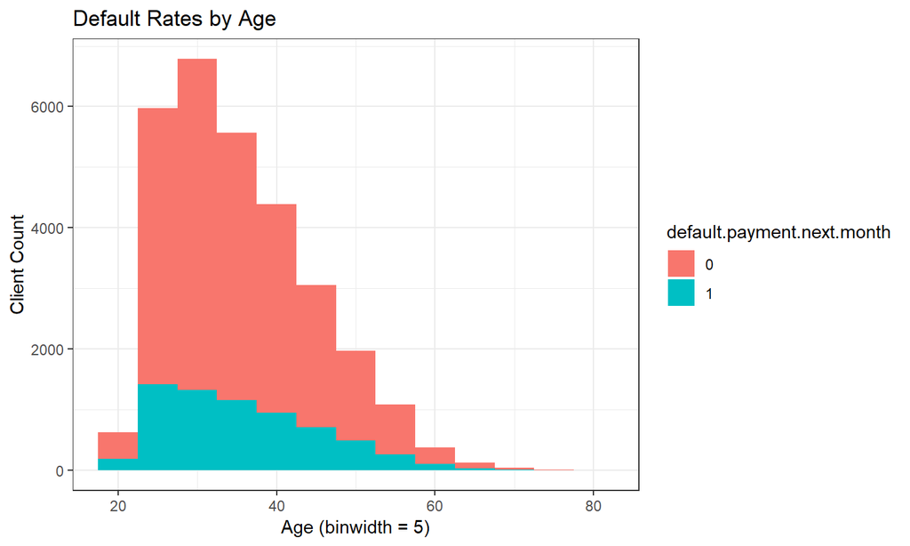

```r
ggplot(cr, aes(x = AGE, fill = default.payment.next.month)) + theme_bw() + geom_histogram(binwidth = 5) + labs(y = "Client Count", x = "Age (binwidth = 5)", title = "Default Rates by Age")
```

## Visualization 7

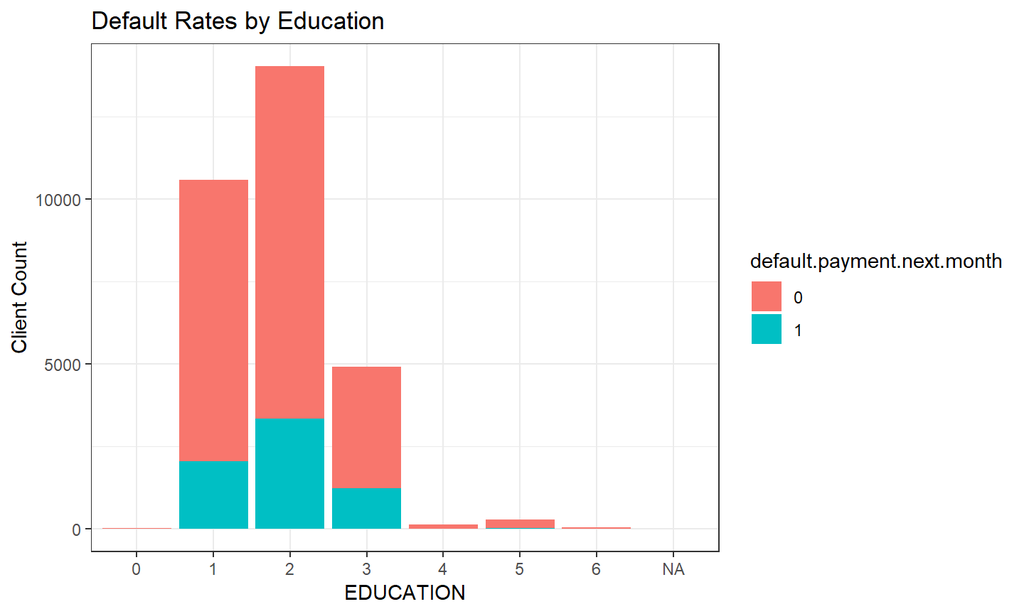

```r
ggplot(cr, aes(x = EDUCATION, fill = default.payment.next.month)) + theme_bw() + geom_bar() + labs(y = "Client Count", title = "Default Rates by Education")
```

## Visualization 8

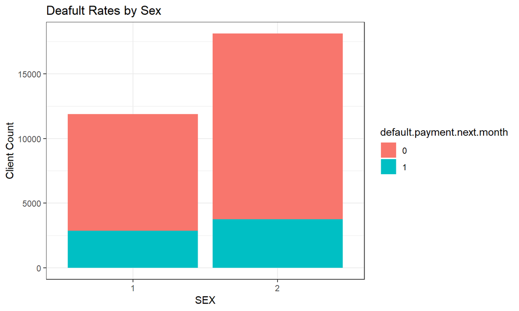

```r
ggplot(cr, aes(x = SEX, fill = default.payment.next.month)) + theme_bw() + geom_bar() + labs(y = "Client Count", title = "Deafult Rates by Sex")
```

## Visualization 9

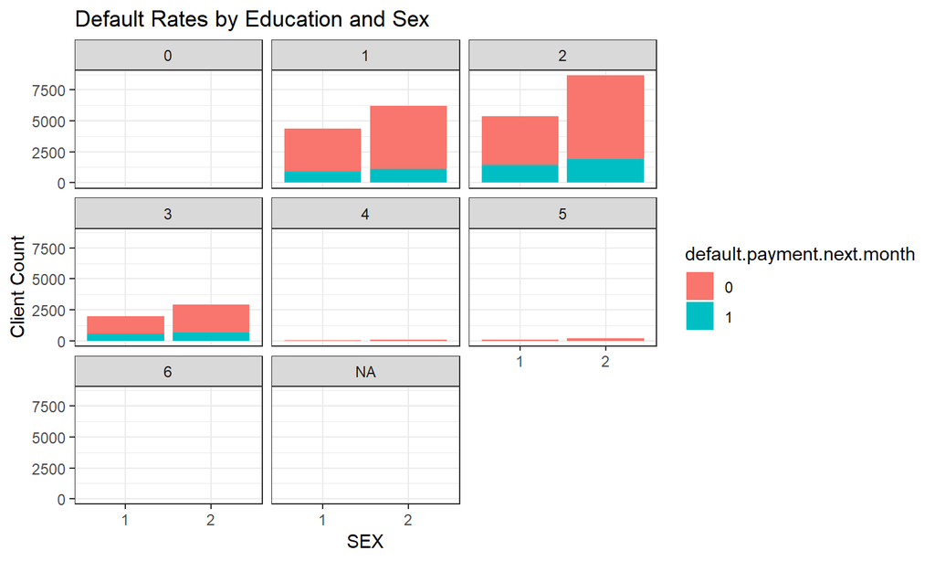

```r
ggplot(cr, aes(x = SEX, fill = default.payment.next.month)) + theme_bw() + facet_wrap(~ EDUCATION) + geom_bar() + labs(y = "Client Count", title = "Default Rates by Education and Sex")
```

## Visualization 10

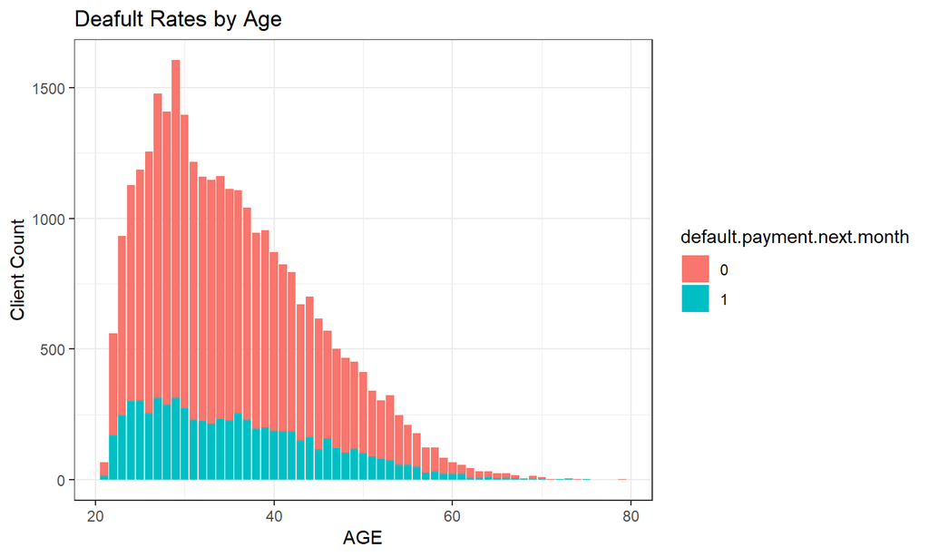

```r
ggplot(cr, aes(x = AGE, fill = default.payment.next.month)) + theme_bw() + geom_bar() + labs(y = "Client Count", title = "Deafult Rates by Age")
```

## Visualization 11

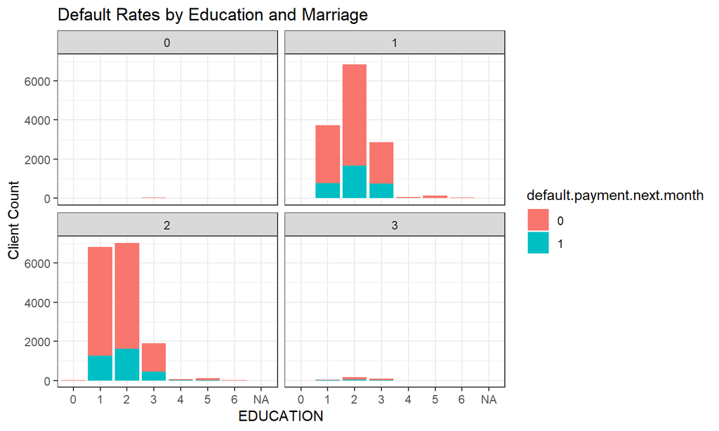

```r
ggplot(cr, aes(x = EDUCATION, fill = default.payment.next.month)) + theme_bw() + facet_wrap(~ MARRIAGE) + geom_bar() + labs(y = "Client Count", title = "Default Rates by Education and Marriage")
```

## Visualization 12

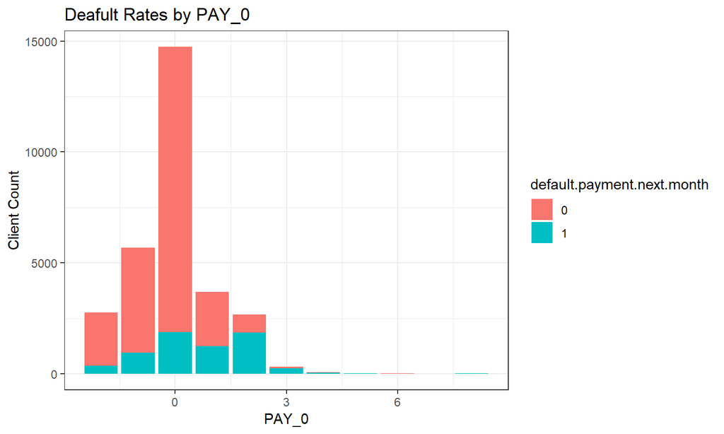

```r
ggplot(cr, aes(x = PAY_0, fill = default.payment.next.month)) + theme_bw() + geom_bar() + labs(y = "Client Count", title = "Deafult Rates by PAY_0")
```

## Visualization 13

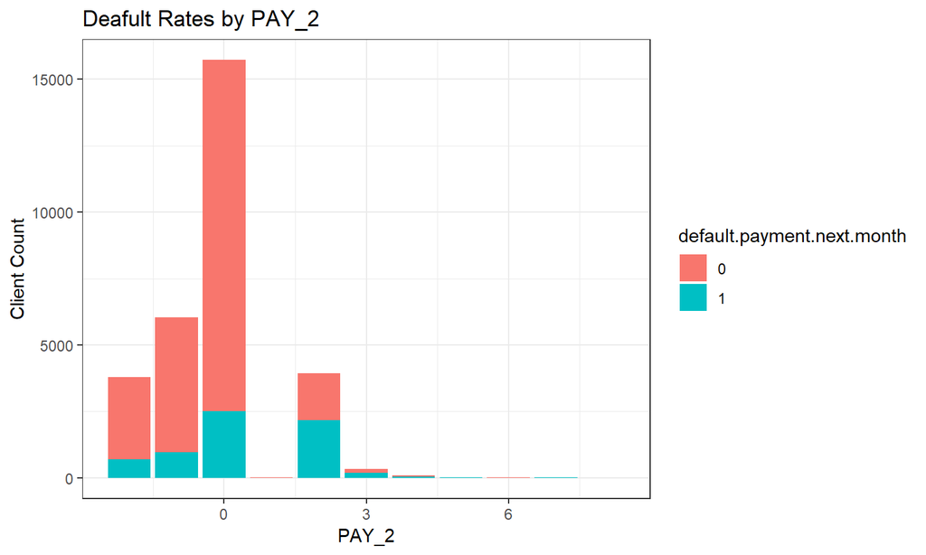

```r
ggplot(cr, aes(x = PAY_2, fill = default.payment.next.month)) + theme_bw() + geom_bar() + labs(y = "Client Count", title = "Deafult Rates by PAY_2")
```

## Visualization 14

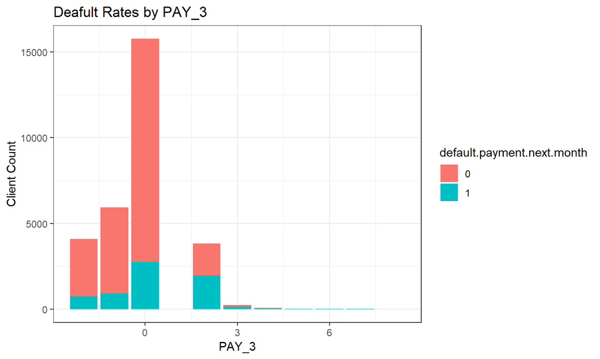

```r
ggplot(cr, aes(x = PAY_3, fill = default.payment.next.month)) + theme_bw() + geom_bar() + labs(y = "Client Count", title = "Deafult Rates by PAY_3")
```

## Visualization 15

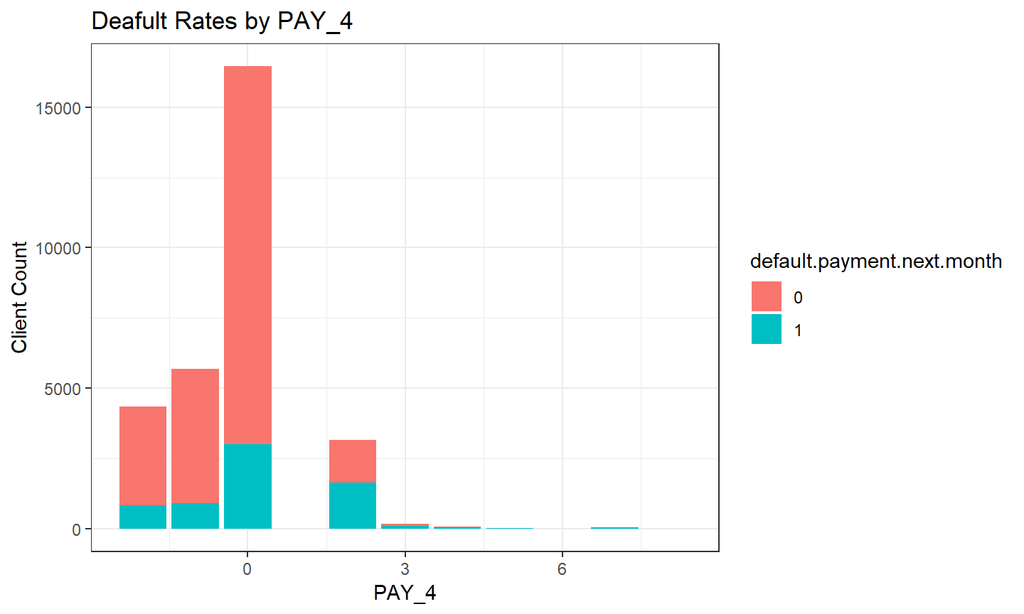

```r
ggplot(cr, aes(x = PAY_4, fill = default.payment.next.month)) + theme_bw() + geom_bar() + labs(y = "Client Count", title = "Deafult Rates by PAY_4")
```

## Missing Values

There are many ways to handle missing values with numeric variables. You can either impute the median, impute the mean, or remove those missing values. The way I did it here was by using my quick clean function from my package, using complete cases, and using a loop to impute the median.

```r
sum(is.na(cr))
```

```
## [1] 4
```

## Using my quick clean function (1)

```r
library(kwes1)
cr1 = quick_clean(cr,1)
sum(is.na(cr1))
```

```
## [1] 0
```

## Using complete cases (2)

```r
sum(is.na(cr))
```

```
## [1] 4
```

```r
cr2 = cr[complete.cases(cr),]
sum(is.na(cr2))
```

```
## [1] 0
```

## Imputing the Median (3)

```r
for(i in 1:ncol(cr))
    {
    cr[cr ==" "]= NA
    missval <- sum(is.na(cr[i]))
    if(missval > 0)
      {
      if(is.numeric(cr[[i]]) == FALSE)
        {
        levels=unique(cr[,i])
        cr[,i][is.na(cr[,i])]=levels[which.max(tabulate(match(cr[,i], x = levels)))]
      }
      else
      {
        cr3 <- preProcess(cr, method='medianImpute')
      }
    }
}
```

## Result

```r
sum(is.na(cr3))
```

```
## [1] 0
```

## Model Training and Model Tuning

## Creating trainging and testing datasets

```r
names(cr)[25] = "target"
splitIndex <-createDataPartition(cr$target, p=.70, list = FALSE, times = 1)
train <-cr[splitIndex,]
test <- cr[-splitIndex,]
```

## Creating an undersampled dataset

```r
train1 = train[train$target == "1",]
train0 = train[train$target == '0',]
n0 = nrow(train0)
n1 = nrow(train1)
train00 = train0[sample(1:n0,n1),]
train_under = rbind(train00, train1)
```

## Random Forest 1

```r
library(randomForest)
set.seed(215)
fit <- randomForest(as.factor(default.payment.next.month) ~ SEX + AGE + EDUCATION + PAY_0 + PAY_2 +
                                            MARRIAGE,
                      data=cr1,
                      importance=TRUE,
                      ntree=2000)
```

## Glm Model

```r
Gridglm = expand.grid(alpha = 0:1, lambda = seq(0.0001, 0.1, length = 10))
Control = trainControl(method = "cv", number = 7)
glmdefa = train(default.payment.next.month~., cr1, method = "glmnet")
glmtuneda = train(default.payment.next.month~., cr1, method ="glmnet",tuneGrid = Gridglm, trControl = Control)
max(glmtuneda$results$Accuracy) > max(glmdefa$results$Accuracy)
```

```
## [1] TRUE
```

```r
max(glmtuneda$results$Accuracy)
```

```
## [1] 0.8104664
```

```r
max(glmdefa$results$Accuracy)
```

```
## [1] 0.809504
```